# Checking Covariates Balance - Entering Cruise Experiment

Comparing hours with entering cruise traffic to hours without. Adjusting for calendar and weather indicators.

Marie-Abèle Bind https://scholar.harvard.edu/marie-abele (Biostatistics Center, Massachusetts General Hospital)https://biostatistics.massgeneral.org/faculty/marie-abele-bind-phd/ , Marion Leroutier https://www.parisschoolofeconomics.eu/en/leroutier-marion/work-in-progress/ (Misum, Stockholm School of Economics)https://www.hhs.se/en/persons/l/leroutier-marion/ , Léo Zabrocki https://lzabrocki.github.io/ (Paris School of Economics)https://www.parisschoolofeconomics.eu/fr/zabrocki-leo/  
2021-11-02

In this document, we take great care providing all steps and R codes required to check whether our most matching procedure achieved balance. We compare hours where:

- treated units are hours with positive entering cruise traffic in t.
- control units are hours without entering cruise traffic in t.

We adjust for calendar calendar indicator and weather confouding factors.

**Should you have any questions, need help to reproduce the analysis or find coding errors, please do not hesitate to contact us at leo.zabrocki@psemail.eu and marion.leroutier@psemail.eu.**

# Required Packages

- the [R](https://www.r-project.org/) programming language
- [RStudio](https://rstudio.com/), an integrated development environment for R, which will allow you to knit the `5_script_checking_balance_figures.Rmd` file and interact with the R code chunks
- the [R Markdown](https://rmarkdown.rstudio.com/) package
- and the [Distill](https://rstudio.github.io/distill/) package which provides the template for this document.

Once everything is set up, we have to load the following packages:

```r
# load required packages
library(knitr) # for creating the R Markdown document
library(here) # for files paths organization
library(tidyverse) # for data manipulation and visualization
library(ggridges) # for ridge density plots
library(Cairo) # for printing customed police of graphs
library(patchwork) # combining plots
```

We finally load our customed `ggplot2` theme for graphs:

```r
# load ggplot customed theme
source(here::here("2.scripts", "4.custom_ggplot2_theme", "script_custom_ggplot_theme.R"))
```

The theme is based on the fantastic [hrbrthemes](https://hrbrmstr.github.io/hrbrthemes/index.html) package. If you do not want to use this theme or are unable to install it because of fonts issues, you can use the `theme_bw()` already included in the `ggplot2` package.

# Preparing the Data

We load the matched data:

```r
# load matched data
data_matched <- readRDS(here::here("1.data", "2.data_for_analysis", "1.matched_data", "1.experiments_cruise", "1.experiment_entry_cruise", "matched_data_entry_cruise.rds"))
```

# Figures for Covariates Distribution for Treated and Control Units

We check whether coviariates balance was achieved with the thresholds we defined for our matching procedure. We plot distributions of weather and calendar variables (Lags 0-2) and pollutants (Lags 1-2) for treated and control groups.

### Weather Covariates

For continuous weather covariates, we draw boxplots for treated and control groups:

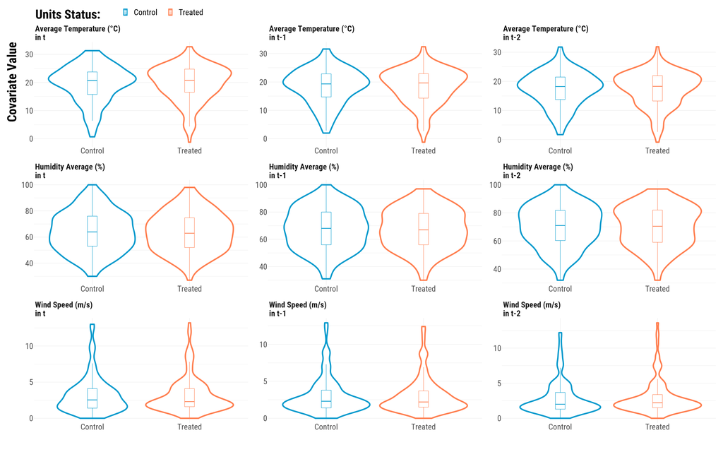

```r
# we select control variables and store them in a long dataframe
data_weather_continuous_variables <- data_matched %>%
  select(temperature_average, temperature_average_lag_1, temperature_average_lag_2,
         humidity_average, humidity_average_lag_1, humidity_average_lag_2,
         wind_speed, wind_speed_lag_1, wind_speed_lag_2,
         is_treated) %>%
  pivot_longer(cols = -c(is_treated), names_to = "variable", values_to = "values") %>%
  mutate(new_variable = NA %>%
           ifelse(str_detect(variable, "temperature_average"), "Average Temperature (°C)",.) %>%
           ifelse(str_detect(variable, "humidity_average"), "Humidity Average (%)",.) %>%
           ifelse(str_detect(variable, "wind_speed"), "Wind Speed (m/s)",.)) %>%
  mutate(time = "\nin t" %>%
           ifelse(str_detect(variable, "lag_1"), "\nin t-1", .) %>%
           ifelse(str_detect(variable, "lag_2"), "\nin t-2", .)) %>%
  mutate(variable = paste(new_variable, time, sep = " ")) %>%
  mutate(is_treated = if_else(is_treated==TRUE, "Treated", "Control"))

graph_boxplot_continuous_weather <- ggplot(data_weather_continuous_variables, aes(x = is_treated, y = values, colour = is_treated)) +
  geom_violin(size =  2) +
  geom_boxplot(width=0.1, outlier.shape=NA) +
  scale_color_manual(values=c("deepskyblue3", "coral")) +
  ylab("Covariate Value") +
  xlab("") +
  labs(colour = "Units Status:") +
  facet_wrap(~variable, scale = "free", ncol = 3) +
  custom_theme +
  theme(
    # axis titles parameters
    axis.title.x = element_text(size=50, face = "bold", margin = margin(t = 20, r = 0, b = 0, l =0)),
    axis.title.y = element_text(size=50, face = "bold", margin = margin(t = 0, r = 20, b = 0, l = 0)),
    # facet texts
    strip.text.x = element_text(size=32, face = "bold"),
    strip.text.y = element_text(size=32, face = "bold"),
    # axis texts
    axis.text.x = element_text(size=32),
    axis.text.y = element_text(size=32),
    # legend parameters
    legend.position = "top", legend.justification = "left", legend.direction = "horizontal",
    legend.title = element_text(size=50, face = "bold"),
    legend.text = element_text(size=32),
    plot.margin = margin(1, 1, 1, 1, "cm"))

# we print the graph
graph_boxplot_continuous_weather
```

```r
# save the graph
ggsave(graph_boxplot_continuous_weather, filename = here::here("3.outputs", "1.figures", "2.experiments_cruise", "1.experiment_entry_cruise", "1.checking_matching_procedure", "graph_boxplot_continuous_weather.pdf"), width = 50, height = 50, units = "cm", device = cairo_pdf)
```

For the rainfall dummy and the wind direction categories, we plot the proportions:

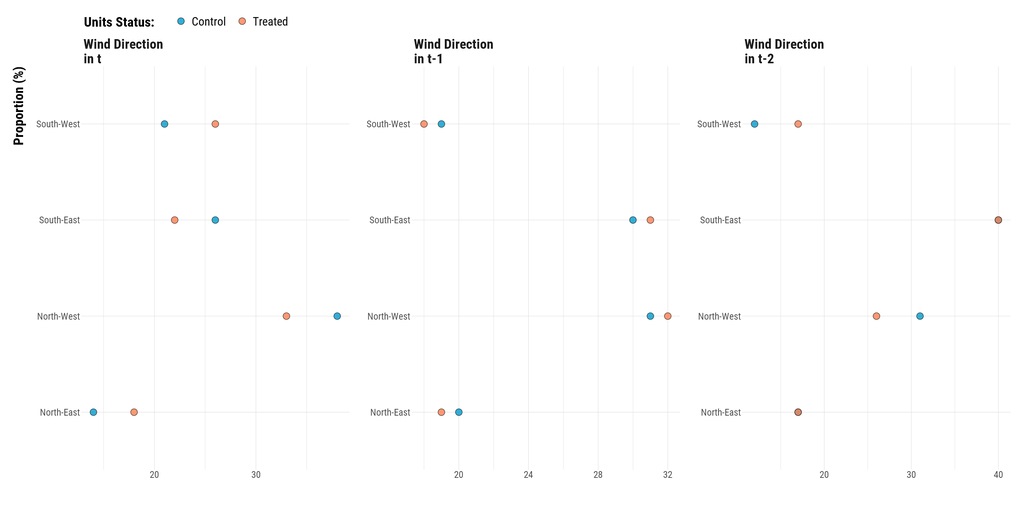

```r
# we select the rainfall variables
data_weather_categorical <- data_matched %>%
  select(rainfall_height_dummy, rainfall_height_dummy_lag_1, rainfall_height_dummy_lag_2,
         wind_direction_categories, wind_direction_categories_lag_1, wind_direction_categories_lag_2,
         is_treated) %>%
  mutate_at(vars(rainfall_height_dummy:rainfall_height_dummy_lag_2), ~ ifelse(.==1, "True", "False")) %>%
  mutate_all(~ as.character(.)) %>%
  pivot_longer(cols = -c(is_treated), names_to = "variable", values_to = "values") %>%
  # group by is_treated, variable and values
  group_by(is_treated, variable, values) %>%
  # compute the number of observations
  summarise(n = n()) %>%
  # compute the proportion
  mutate(freq = round(n / sum(n)*100, 0)) %>%
  ungroup() %>%
  filter(!(variable %in% c("rainfall_height_dummy", "rainfall_height_dummy_lag_1", "rainfall_height_dummy_lag_2") & values == "False")) %>%
  mutate(new_variable = NA %>%
           ifelse(str_detect(variable, "wind"), "Wind Direction",.) %>%
           ifelse(str_detect(variable, "rainfall"), "Rainfall Dummy",.)) %>%
  mutate(time = "\nin t" %>%
           ifelse(str_detect(variable, "lag_1"), "\nin t-1", .) %>%
           ifelse(str_detect(variable, "lag_2"), "\nin t-2", .)) %>%
  mutate(variable = paste(new_variable, time, sep = " ")) %>%
  mutate(is_treated = if_else(is_treated==TRUE, "Treated", "Control"))


# build the graph for wind direction
graph_categorical_wd_weather <- data_weather_categorical %>%
  filter(new_variable == "Wind Direction") %>%
  ggplot(., aes(x = freq, y = values, fill = is_treated)) +
  geom_point(shape = 21, size = 6, alpha = 0.8) +
  scale_fill_manual(values = c("deepskyblue3", "coral")) +
  facet_wrap(~ variable, scales = "free") +
  ylab("Proportion (%)") +
  xlab("") +
  labs(fill = "Units Status:") +
  custom_theme +
  theme(legend.position = "top", legend.justification = "left", legend.direction = "horizontal")

# we print the graph
graph_categorical_wd_weather
```

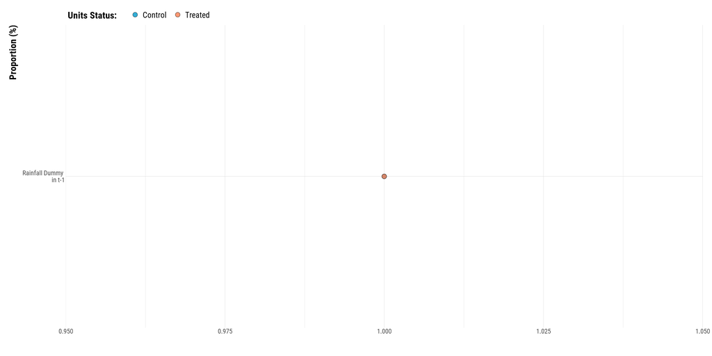

```r
# build the graph for rainfall dummy
graph_categorical_rainfall_weather <- data_weather_categorical %>%
  filter(new_variable == "Rainfall Dummy") %>%
  ggplot(., aes(x = freq, y = variable, fill = is_treated)) +
  geom_point(shape = 21, size = 6, alpha = 0.8) +
  scale_fill_manual(values = c("deepskyblue3", "coral")) +
  ylab("Proportion (%)") +
  xlab("") +
  labs(fill = "Units Status:") +
  custom_theme +
  theme(legend.position = "top", legend.justification = "left", legend.direction = "horizontal")

# we print the graph
graph_categorical_rainfall_weather
```

```r
# combine plots
graph_categorical_weather <- graph_categorical_wd_weather / graph_categorical_rainfall_weather +
  plot_annotation(tag_levels = 'A') & theme(plot.tag = element_text(size = 30, face = "bold"))


# save the graph
ggsave(graph_categorical_weather, filename = here::here("3.outputs", "1.figures", "2.experiments_cruise", "1.experiment_entry_cruise", "1.checking_matching_procedure", "graph_categorical_weather.pdf"),
       width = 60, height = 40, units = "cm", device = cairo_pdf)
```

For pollutants:

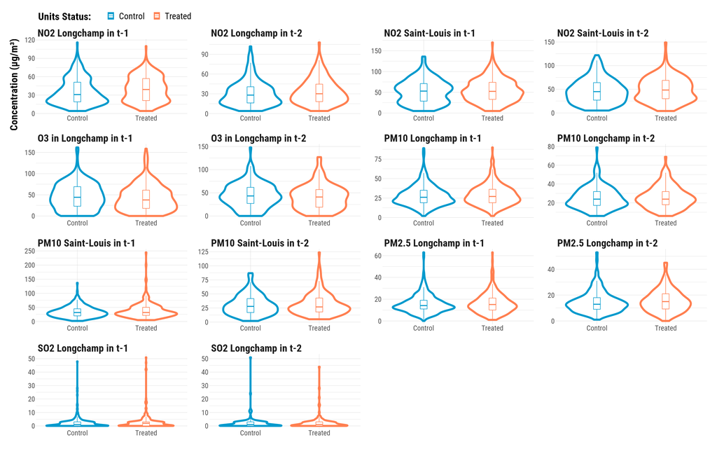

```r
# we select control variables and store them in a long dataframe
data_pollutant_variables <- data_matched %>%
  select(mean_no2_l:mean_o3_l, mean_no2_l_lag_1:mean_o3_l_lag_1,
         mean_no2_l_lag_2:mean_o3_l_lag_2,
         is_treated) %>%
  # transform the data to long to compute the proportion of observations for each variable
  pivot_longer(cols = -c(is_treated), names_to = "variable", values_to = "values") %>%
  mutate(is_treated = ifelse(is_treated=="TRUE", "Treated", "Control")) %>%
  mutate(pollutant = NA %>%
           ifelse(str_detect(variable, "no2_l"), "NO2 Longchamp",.) %>%
           ifelse(str_detect(variable, "no2_sl"), "NO2 Saint-Louis",.) %>%
           ifelse(str_detect(variable, "o3"), "O3 in Longchamp",.) %>%
           ifelse(str_detect(variable, "pm10_l"), "PM10 Longchamp",.) %>%
           ifelse(str_detect(variable, "pm10_sl"), "PM10 Saint-Louis",.) %>%
            ifelse(str_detect(variable, "pm25"), "PM2.5 Longchamp",.) %>%
           ifelse(str_detect(variable, "so2"), "SO2 Longchamp",.)) %>%
  mutate(time = "in t-1" %>%
           ifelse(str_detect(variable, "lag_2"), "in t-2", .)) %>%
  mutate(variable = paste(pollutant, time, sep = " "))


# second graph for hourly pollutants
graph_boxplot_pollutants_hourly <- data_pollutant_variables %>%
  ggplot(., aes(x = is_treated, y = values, colour = is_treated)) +
  geom_violin(size = 2) +
  geom_boxplot(width=0.1, outlier.shape=NA) +
  scale_color_manual(values=c("deepskyblue3", "coral")) +
  ylab("Concentration (µg/m³)") +
  xlab("") +
  labs(colour = "Units Status:") +
  facet_wrap(~variable, scale = "free", ncol = 4) +
  custom_theme +
  theme(legend.position = "top", legend.justification = "left", legend.direction = "horizontal")

# we print the graph
graph_boxplot_pollutants_hourly
```

```r
# save the graph
ggsave(graph_boxplot_pollutants_hourly, filename = here::here("3.outputs", "1.figures", "2.experiments_cruise", "1.experiment_entry_cruise", "1.checking_matching_procedure", "graph_boxplot_pollutants_hourly.pdf"),
       width = 80, height = 60, units = "cm", device = cairo_pdf)
```

### Calendar Indicator

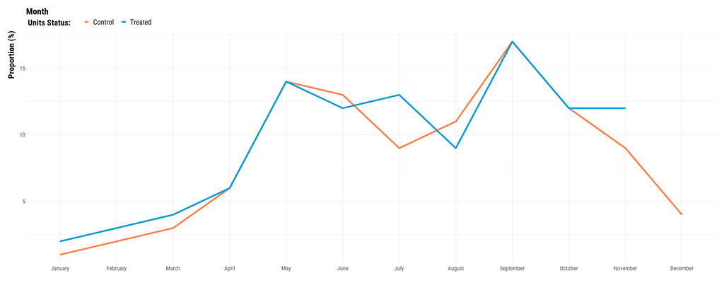

```r
# compute the proportions of observations belonging to each month by treatment status
data_month <- data_matched %>%
  mutate(is_treated = ifelse(is_treated=="TRUE", "Treated", "Control")) %>%
  select(month, is_treated) %>%
  mutate(month = recode(month, `1` = "January",
                               `2` = "February",
                               `3` = "March",
                               `4` = "April",
                               `5` = "May",
                               `6` = "June",
                               `7` = "July",
                               `8` = "August",
                               `9` = "September",
                               `10` = "October",
                               `11` = "November",
                               `12` = "December") %>%
           fct_relevel(., "January", "February", "March","April", "May", "June", "July", "August", "September", "October", "November", "December")) %>%
  pivot_longer(., -is_treated) %>%
  group_by(name, is_treated, value) %>%
  summarise(n = n()) %>%
  mutate(proportion = round(n / sum(n)*100,0)) %>%
  ungroup()

# we plot the data using cleveland dot plots
graph_month <- ggplot(data_month, aes(x = as.factor(value), y = proportion, colour = is_treated, group = is_treated)) +
  geom_line(size = 2) +
  scale_colour_manual(values=c("coral", "deepskyblue3"), guide = guide_legend(reverse = FALSE)) +
  ggtitle("Month") +
  ylab("Proportion (%)") +
  xlab("") +
  labs(colour = "Units Status:") +
  custom_theme +
  theme(legend.position = "top", legend.justification = "left", legend.direction = "horizontal")

# we print the graph
graph_month
```

We plot the proportions of observations belonging to each year by treatment status:

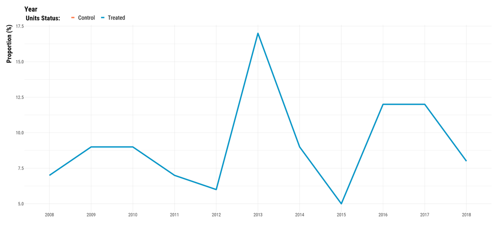

```r
# compute the proportions of observations belonging to each year by treatment status
data_year <- data_matched %>%
  mutate(is_treated = ifelse(is_treated=="TRUE", "Treated", "Control")) %>%
  select(
         year, is_treated) %>%
  pivot_longer(., -is_treated) %>%
  group_by(name, is_treated, value) %>%
  summarise(n = n()) %>%
  mutate(proportion = round(n / sum(n)*100,0)) %>%
  ungroup()

# we plot the data using cleveland dot plots
graph_year <- ggplot(data_year, aes(x = as.factor(value), y = proportion, colour = is_treated, group = is_treated)) +
  geom_line(size = 2) +
  scale_colour_manual(values=c("coral", "deepskyblue3"), guide = guide_legend(reverse = FALSE)) +
  ggtitle("Year") +
  ylab("Proportion (%)") +
  xlab("") +
  labs(colour = "Units Status:") +
  custom_theme +
  theme(legend.position = "top", legend.justification = "left", legend.direction = "horizontal")

# we print the graph
graph_year
```

We combine and save the two previous:

```r
# combine plots
graph_month_year <- graph_month / graph_year +
  plot_annotation(tag_levels = 'A') & theme(plot.tag = element_text(size = 30, face = "bold"))

# save the plot
ggsave(graph_month_year, filename = here::here("3.outputs", "1.figures", "2.experiments_cruise", "1.experiment_entry_cruise", "1.checking_matching_procedure", "graph_month_year.pdf"),
       width = 40, height = 40, units = "cm", device = cairo_pdf)
```